## Introduction.

In the light of two most recent and deadliest mass shootings in the history of a country that has more guns than there are people, a lot of people are seeking answers to the deadly scourge that is the blatant disregard for human life that has plagued America for years. To broach this sensitive topic, we are embarking on a quest to find what went wrong through the analysis of these incidents since 1966.

There is no specific definition for mass shootings, so we have defined it as any shooting incident occurring in a public space in which three or more people suffer injury or death. We have provided a visual of the locations of these mass-shooting incidents within the United States.

[figure not shown]

Here is a table showing the number of victims recorded per state up to date.

#### States with most rampant incidents.

| state | victims_to_date |
| --- | --- |
| Nevada | 612 |
| California | 400 |
| Texas | 316 |
| Florida | 275 |
| Colorodo | 151 |
| Washington | 112 |
| New York | 100 |
| Georgia | 96 |
| Virginia | 89 |

In recent years, there have been many mass shooting reports in the news. These events, due to their grim nature, have caught more media attention than usual and thus it may seem like they have become more sudden and commonplace. Therefore, we felt inclined to analyze the number of mass shootings to see how far widespread they have become. Below is a barchart showing the yearly prevalence of incidents of firearm violence over the past half century:

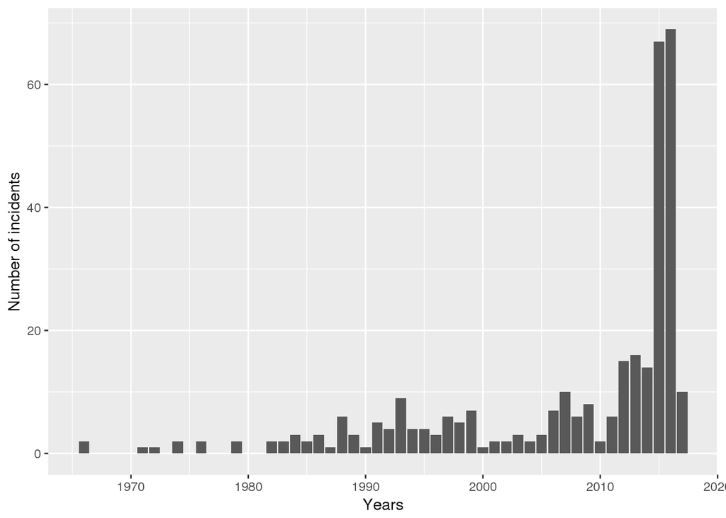

2017 has had a significantly lesser number of individual incidents than the past five years yet it has been the most deadly so far in terms of the number of fatalities and injuries reported. It is worth noting that our data includes the latest shooting which happened at a Church in Texas on 5th November 2017.

## How Bad Has It Gotten?

Next we wanted to see if mass shootings are becoming more deadly. Below, we included a line graph which shows number of fatalities reported per mass shooting over time. We also included another graph that shows the number of people injured for every mass shooting incident over time. We combined both parameters in an overplotted linegraph in the last graph, which contrasts the type of victims in each mass shooting (those who died or had injuries) over the years from 1966 to present time.

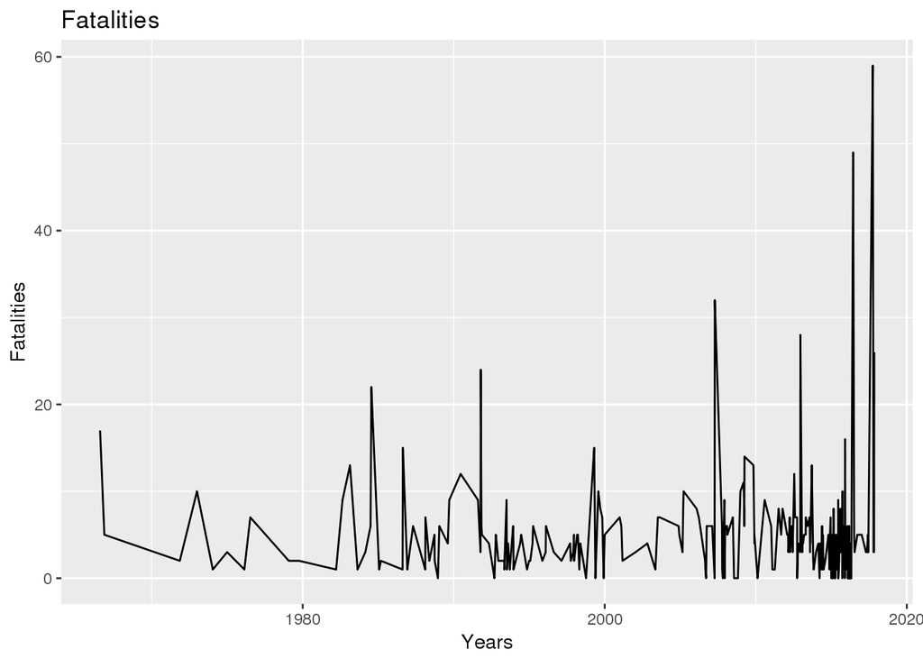

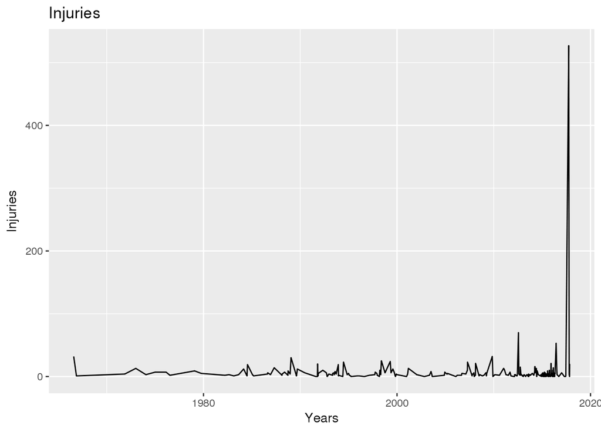

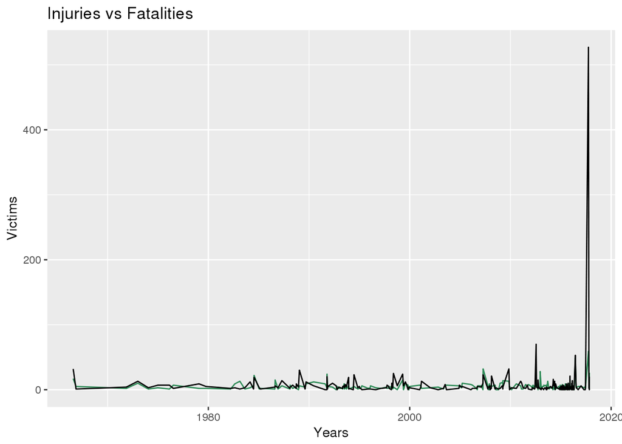

As we can see, the number of fatalities has generally increased throughout the years, so we can say that yes, mass shootings have become more deadly. However the graphs of the number of people injured and victims looked very similar with generally steady trend lines save for the three spikes at the end, which correspond to some of the most infamous mass shootings that have occurred in modern U.S. history. The first is the 2012 Aurora shooting in which a gunman opened fire to a crowd watching the midnight screening of the Dark Knight Rises in Colorado, the second spike is the Orlando Pulse shooting which occurred at a gay nightclub last year in 2016. The last spike, which is much higher than any other incident is the most deadly mass shooting to date. It occurred earlier this year in October, when a gunman opened fire on an outdoor country music festival in Las Vegas, which left 59 people dead and 527 people injured.

## Gun Violence and gun control.

We also wanted to look at the gun laws in all states and contrast any correlations between the number of victims in these mass shootings and gun ownership per capita at the state level for the different laws. As described in an article we read on the Washington Post, there are five types of gun laws. The first two, the assault weapons ban and the high-capacity magazine ban do not allow the sale of these types of weapons within state lines. The next two types of law, prohibitions for high-risk individuals and prohibitions for individuals with domestic violence convictions prohibit certain people such as those convicted of violent crimes, those with a history of mental health or substance abuse, etc. from obtaining firearms. The last type of gun law is mandatory universal backgrounds checks which, as the name suggest requires everybody that purchases a firearm to obtain a background check.

#### 1. Correlation coefficient:

The correlation coefficient between the number of victims from these incidents and the number of guns per capita in each state is weakly negative. The quest to explore additional underlying patterns between the the explanatory variable, number of guns and the outcome variable, number of victims led us to classify our generic model below into different categories depending on how lax different gun laws are in different states. We color coded this model with the colors distinguishing whether or not states enforced four of the five major gun laws mentioned above. We do acknowledge that our model might be flawed since it doesn’t account for guns which weren’t legally obtained.

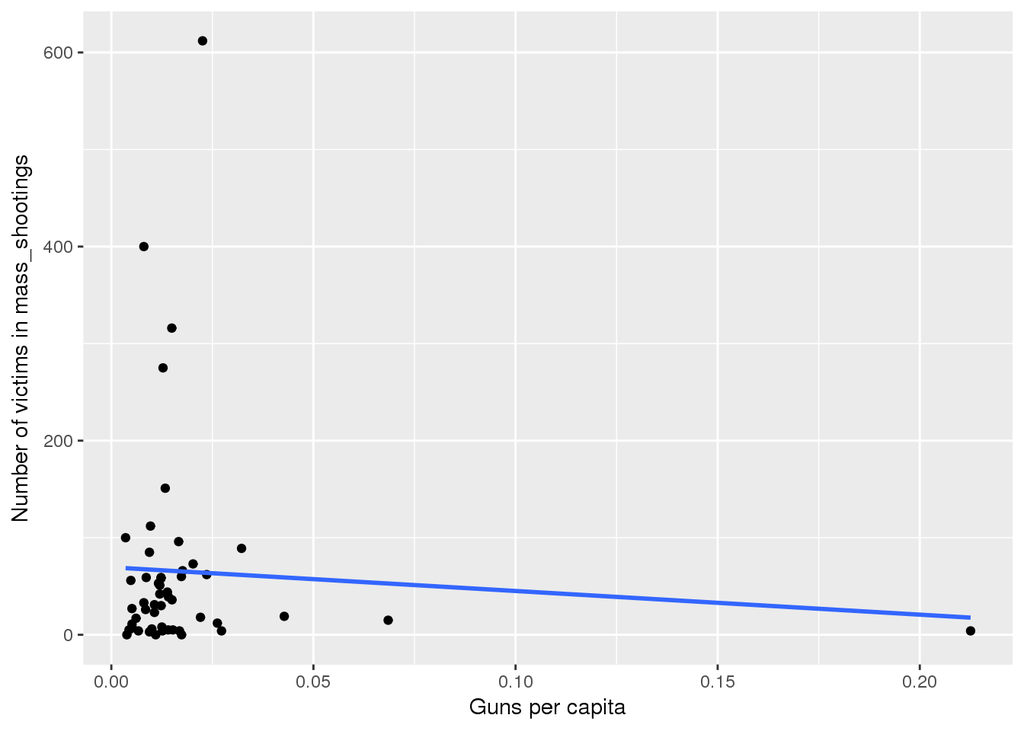

```
## [1] -0.06546555
```

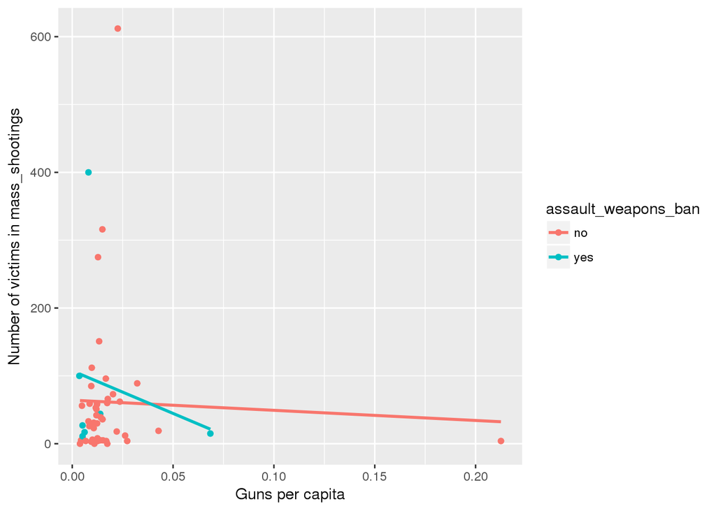

The initial negative relationship between guns per capita and number of casualties still persists when we look at the assault weapons ban. However, the relationship changes to a slightly stronger but still negative one for states that enforce the ban of assault weapons. As gun ownership increases by one unit in states with no assault weapon ban, there is an associated decrease of on average 150 deaths. However, an increase of one unit in gun ownership rates in states with an assault weapon ban corresponds to an associated decrease of 1256 deaths. Generally speaking, there is a stronger inverse relationship between gun ownership and number of casualties from these incidents in states that support the ban than from those that do not.

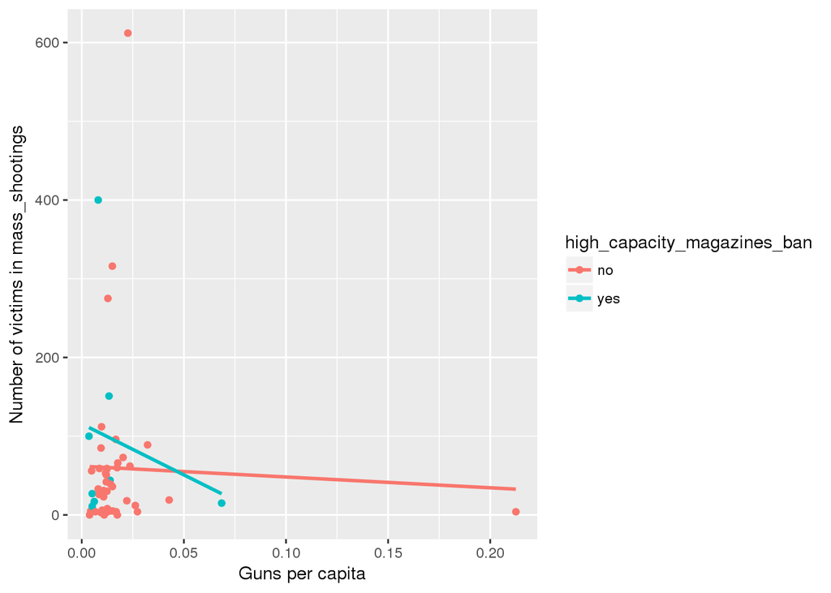

The plot above exhibits a similar pattern to the gun ownership - number of victims vs assault weapons regression model. The associated effect of increasing gun ownership rates in states that restrict detachable high capacity firearm magazines corresponds to a larger decrease in casualties than states with no firearm magazine restrictions.

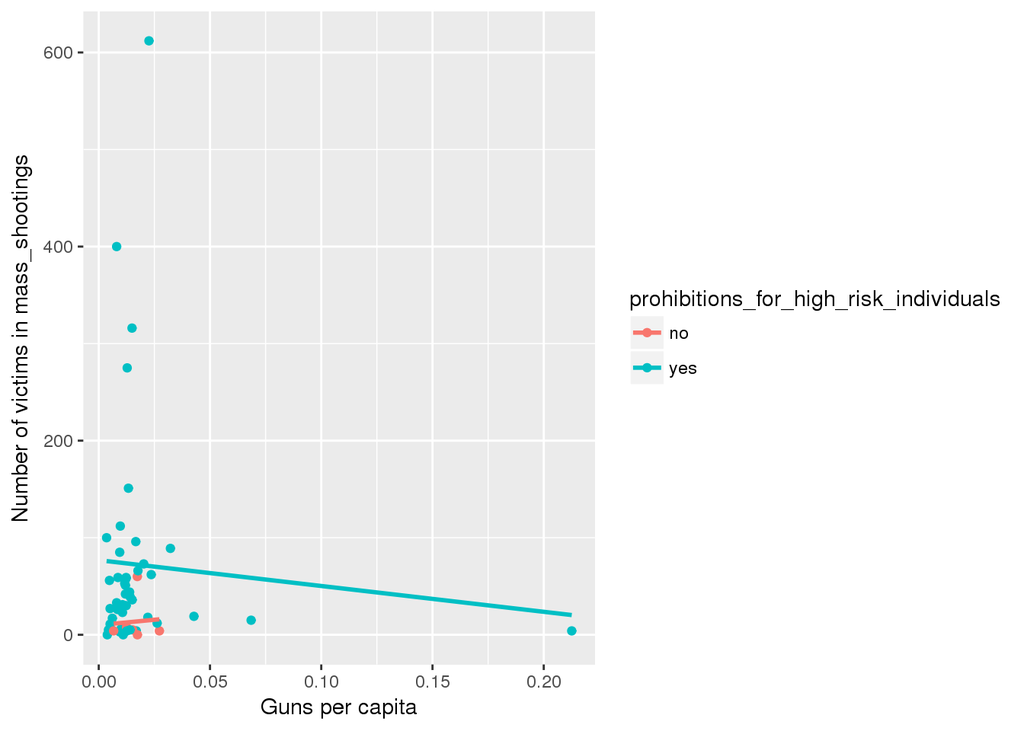

States that enforce prohibitions for high risk individuals had an negative relationship between gun ownership rates and the number of victims from mass shootings while those that don’t enforce them have a positive relationship. For every increase of one in number of guns per capita, there is an associated increase of on average 220 deaths for states with no prohibitions for risky individuals. Conversely, an increase of one in gun ownership corresponds to a decrease of 266 deaths in states where the prohibitions are enforced.

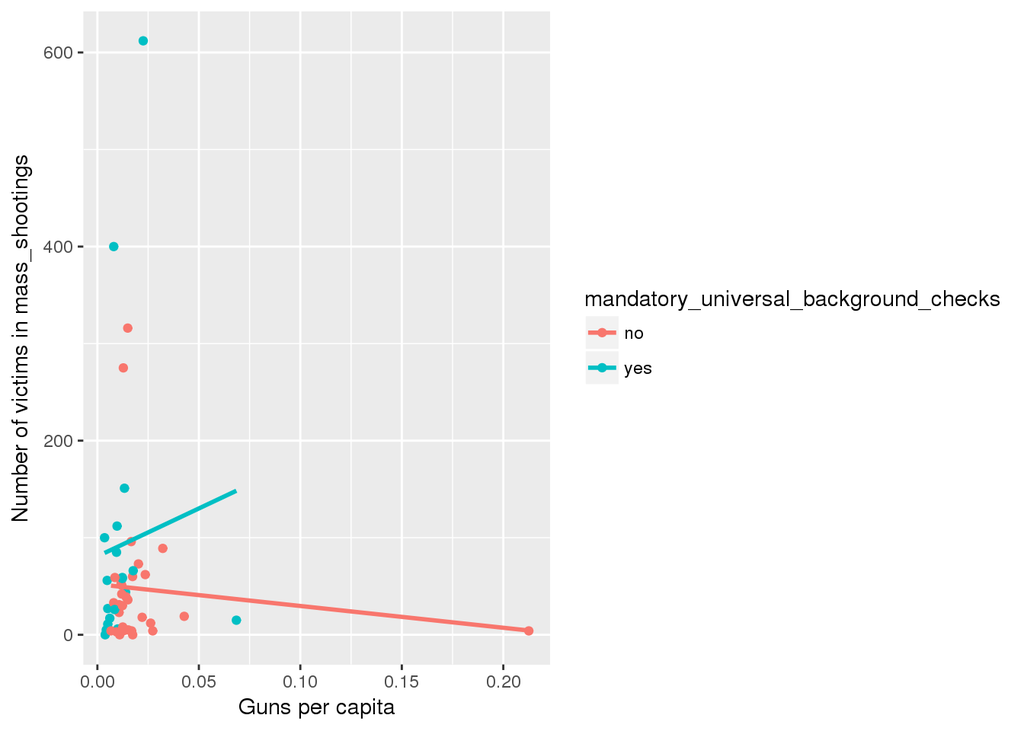

We observed a decrease of on average 224 deaths for a corresponding increase of one in gun ownership among states that have no mandatory background checks. States with mandatory background checks experienced an increase of 987 deaths on average for every increase of one in the number of guns owned per person.

## Supplementary Materials.

In case you would like to read more about this topic, here is a list of all the resources and data that we used: https://www.washingtonpost.com/graphics/2017/national/assault-weapons-laws https://docs.google.com/spreadsheets/d/1s1C2-zqV6n5QndPlu8zFdA4VpPUp-nEd4EvY71oazKQ/edit#gid=3 https://www.theguardian.com/news/datablog/2012/dec/17/how-many-guns-us#data https://www.atf.gov/file/89561/download

## Citations/notes:

You can find the article from the Washington Post we talked about under the Gun Violence and Gun Control section in the supplemetary materials section. <sup>1</sup> https://www.fbi.gov/services/cjis/nics